# Bibliometric Analysis of Small Lakes Research (1990–2024)

Kate Regine Cunanan

2026-04-20

```r
# Load libraries
library(bibliometrix)
library(tidyverse)
library(ggplot2)
library(maps)

# Import raw Scopus data
scopus_raw <- convert2df(
  file = "_small lake__.csv [no keyword limitation]",
  dbsource = "scopus",
  format = "csv"
)
```

```
##
## Converting your scopus collection into a bibliographic dataframe
##
## Done!
##
##
## Generating affiliation field tag AU_UN from C1:  Done!
```

```r
# Run bibliometric analysis
bib_analysis <- biblioAnalysis(scopus_raw, sep = ";")
bib_summary <- summary(bib_analysis, k = 10, pause = FALSE)
```

```
##
##
## MAIN INFORMATION ABOUT DATA
##
##  Timespan                              1898 : 2025
##  Sources (Journals, Books, etc)        2236
##  Documents                             13181
##  Annual Growth Rate %                  0
##  Document Average Age                  15.5
##  Average citations per doc             34.62
##  Average citations per year per doc    2.167
##  References                            715186
##
## DOCUMENT TYPES
##  article               11637
##  book                  117
##  book chapter          356
##  conference paper      370
##  data paper            16
##  editorial             21
##  erratum               4
##  letter                20
##  note                  33
##  review                601
##  short survey          6
##
## DOCUMENT CONTENTS
##  Keywords Plus (ID)                    31456
##  Author's Keywords (DE)                23153
##
## AUTHORS
##  Authors                               31119
##  Author Appearances                    56688
##  Authors of single-authored docs       1228
##
## AUTHORS COLLABORATION
##  Single-authored docs                  1558
##  Documents per Author                  0.424
##  Co-Authors per Doc                    4.3
##  International co-authorships %        25.9
```

[output cut: 163 more lines]

```
##
##
## Most Relevant Keywords
##
##    Author Keywords (DE)      Articles   Keywords-Plus (ID)     Articles
## 1             CLIMATE CHANGE      408 LAKES                        2237
## 2             LAKES               377 ARTICLE                      1351
## 3             EUTROPHICATION      356 CLIMATE CHANGE               1274
## 4             HOLOCENE            330 WATER QUALITY                1245
## 5             PHYTOPLANKTON       294 LAKE                         1226
## 6             ZOOPLANKTON         280 UNITED STATES                1021
## 7             DIATOMS             267 ENVIRONMENTAL MONITORING     1012
## 8             WATER QUALITY       218 CHINA                         975
## 9             LAKE SEDIMENTS      204 EUTROPHICATION                907
## 10            LAKE                196 ECOSYSTEM                     888
```

[figure not shown]

[figure not shown]

[figure not shown]

[figure not shown]

[figure not shown]

```r
p1 <- plot(bib_analysis, k = 10, pause = FALSE)
```

## 1. Introduction

Bibliometric analysis is a quantitative method used to evaluate and map the scientific literature of a specific field. This study uses bibliometric analysis to examine the research landscape on **small lakes** from 1990 to 2024, using data retrieved from the Scopus database.

The analysis aims to identify publication trends, leading authors, influential journals, productive countries, and dominant research themes in the field of small lakes research.

## 2. Data and Methods

Data was retrieved from the **Scopus database** using “small lake*” and related terms as search keywords. The raw dataset consisted of 13,181 records spanning from 1898 to 2025.

The dataset was cleaned using the following steps:

The final cleaned dataset comprises **11,391 documents** published across **1,729 sources** by **28,700 authors**.

All analyses and visualizations were performed in R using the `bibliometrix`, `tidyverse`, and `ggplot2` packages.

## 3. Data Cleaning

The raw dataset retrieved from Scopus consisted of **13,181 records** spanning from 1898 to 2025. Before proceeding with the analysis, the data was inspected and cleaned through the following steps.

### 3.1 Checking for Missing Values

The first step was to check whether key bibliometric fields contained any missing values.

```r
colSums(is.na(scopus_raw[, c("AU", "TI", "PY", "SO", "DE", "ID", "AB", "TC", "CR", "C1")]))
```

```
## AU TI PY SO DE ID AB TC CR C1
##  0  0  0  0  0  0  0  0  0  0
```

All key fields returned zero missing values, indicating that the Scopus export was complete and no imputation was necessary.

### 3.2 Checking Publication Years

Next, the distribution of publication years was examined to identify any anomalous or sparse records.

```r
table(scopus_raw$PY)
```

```
##
## 1898 1926 1943 1947 1948 1956 1961 1965 1967 1970 1971 1972 1973 1974 1975 1976 1977 1978 1979 1980 1981 1982 1983 1984
##    1    1    1    1    2    1    2    1    1    5    7    6   17   11   13   19   21   32   37   40   37   50   56   58
## 1985 1986 1987 1988 1989 1990 1991 1992 1993 1994 1995 1996 1997 1998 1999 2000 2001 2002 2003 2004 2005 2006 2007 2008
##   48   93   79  106   89  117   83  119   99  107  103  170  187  206  206  208  201  220  275  225  285  302  271  285
## 2009 2010 2011 2012 2013 2014 2015 2016 2017 2018 2019 2020 2021 2022 2023 2024 2025
##  345  398  363  459  463  495  532  595  579  601  603  683  727  743  700  390    1
```

The data contained records as far back as 1898, with publication counts remaining very sparse prior to 1990. To ensure a meaningful and consistent trend analysis, the dataset was filtered to include only publications from **1990 onwards**. Additionally, the single record from 2025 was excluded as the year is incomplete and would skew the publication trend downward.

### 3.3 Checking for Duplicates

```r
sum(duplicated(scopus_raw$TI))
```

```
## [1] 72
```

A total of **72 duplicate records** were identified based on document title and were removed to avoid inflating author and citation counts.

### 3.4 Checking Document Types

```r
table(scopus_raw$DT)
```

```
##
##          ARTICLE             BOOK     BOOK CHAPTER CONFERENCE PAPER       DATA PAPER        EDITORIAL          ERRATUM
##            11637              117              356              370               16               21                4
##           LETTER             NOTE           REVIEW     SHORT SURVEY
##               20               33              601                6
```

The dataset contained 11 document types, including articles, reviews, conference papers, book chapters, books, editorials, and others. For bibliometric analysis, only **peer-reviewed articles and reviews** were retained, as these are the most comparable and citable document types in the literature.

### 3.5 Applying the Cleaning Steps

Based on the inspection above, the following cleaning steps were applied:

```r
# Filter by year
scopus_clean <- scopus_raw[scopus_raw$PY >= 1990 & scopus_raw$PY <= 2024, ]

# Keep only Articles and Reviews
scopus_clean <- scopus_clean[scopus_clean$DT %in% c("ARTICLE", "REVIEW"), ]

# Remove duplicates
scopus_clean <- scopus_clean[!duplicated(scopus_clean$TI), ]

# Confirm final dataset dimensions
dim(scopus_clean)
```

```
## [1] 11391    53
```

The cleaned dataset comprises **11,391 documents** ready for bibliometric analysis.

## 4. Descriptive Overview

The following key metrics summarize the dataset:

| Metric | Value |
| --- | --- |
| Timespan | 1990–2024 |
| Total Documents | 11,391 |
| Total Authors | 28,700 |
| Total Sources | 1,729 |
| Annual Growth Rate | 3.53% |
| Average Citations per Document | 33.55 |
| Co-Authors per Document | 4.53 |
| International Co-authorships | 27.71% |

## 5. Visualizations

### 5.1 Annual Scientific Production

[figure not shown]

```r
p1$AnnualScientProd +
  labs(
    title = "Annual Scientific Production on Small Lakes (1990–2024)",
    subtitle = "Based on Scopus database | n = 11,391 documents",
    x = "Year",
    y = "Number of Articles",
    caption = "Source: Scopus | Bibliometric Analysis"
  )
```

### 5.2 Top 10 Most Productive Authors

[figure not shown]

```r
p1$MostProdAuthors +
  labs(
    title = "Top 10 Most Productive Authors in Small Lakes Research",
    subtitle = "Based on Scopus database | n = 11,391 documents",
    x = "Number of Articles",
    y = "Authors",
    caption = "Source: Scopus | Bibliometric Analysis"
  )
```

### 5.3 Top 10 Most Relevant Journals

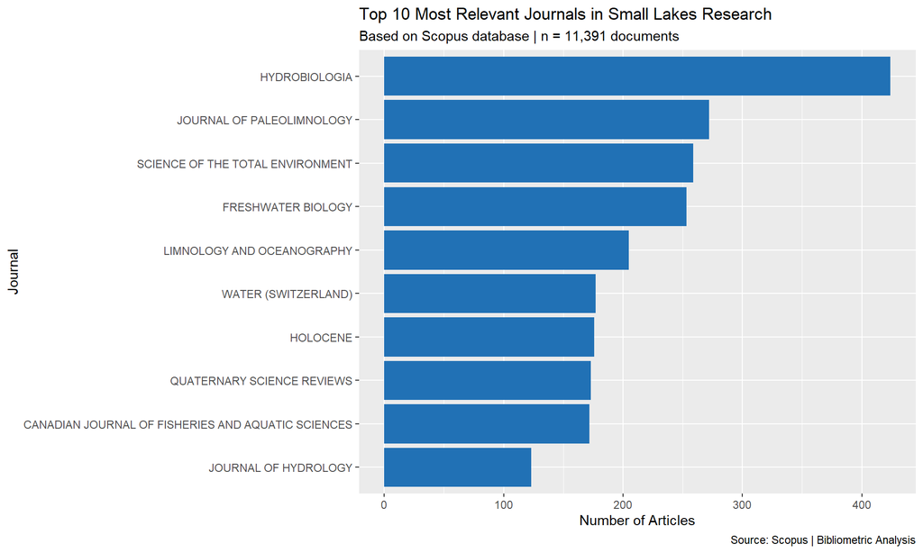

```r
journal_df <- as.data.frame(table(scopus_clean$SO))
colnames(journal_df) <- c("Journal", "Articles")
journal_df <- journal_df[order(-journal_df$Articles), ][1:10, ]

ggplot(journal_df, aes(x = reorder(Journal, Articles), y = Articles)) +
  geom_bar(stat = "identity", fill = "#2171b5") +
  coord_flip() +
  labs(
    title = "Top 10 Most Relevant Journals in Small Lakes Research",
    subtitle = "Based on Scopus database | n = 11,391 documents",
    x = "Journal",
    y = "Number of Articles",
    caption = "Source: Scopus | Bibliometric Analysis"
  )
```

### 5.4 Country Scientific Production

[figure not shown]

```r
library(maps)

country_df <- as.data.frame(bib_analysis$Countries)
colnames(country_df) <- c("Country", "Articles")
country_df$Country <- stringr::str_to_title(country_df$Country)

world_map <- map_data("world")
country_df$Country[country_df$Country == "Usa"] <- "USA"
country_df$Country[country_df$Country == "United Kingdom"] <- "UK"

map_merged <- left_join(world_map, country_df, by = c("region" = "Country"))

ggplot(map_merged, aes(x = long, y = lat, group = group, fill = Articles)) +
  geom_polygon(color = "white", linewidth = 0.1) +
  scale_fill_gradient(
    low = "#c6dbef", high = "#08306b",
    na.value = "gray90",
    name = "Articles"
  ) +
  labs(
    title = "Country Scientific Production on Small Lakes Research",
    subtitle = "Based on Scopus database | n = 11,391 documents",
    caption = "Source: Scopus | Bibliometric Analysis"
  )
```

### 5.5 Top 20 Author Keywords

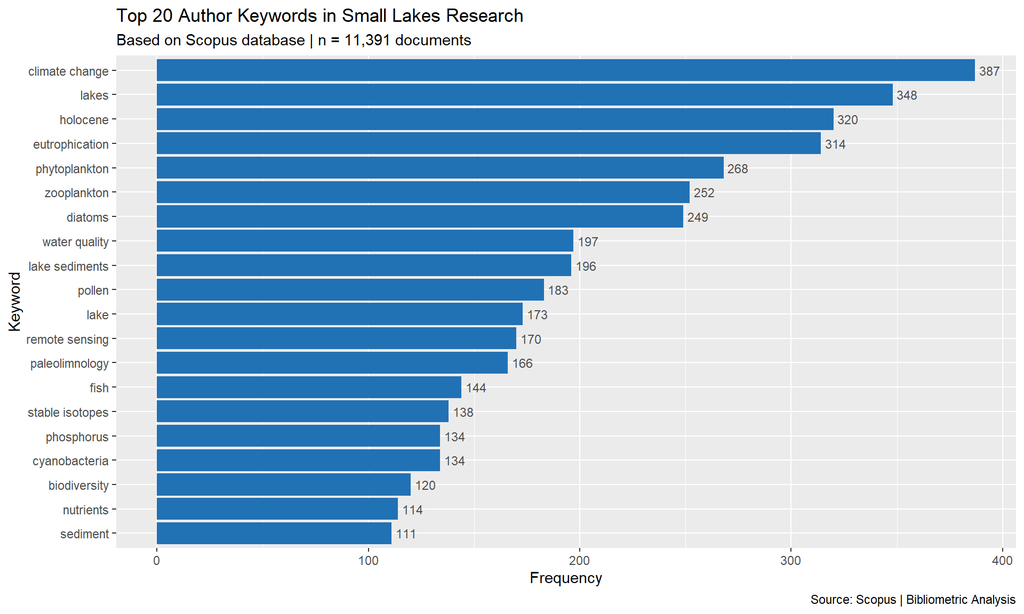

```r
keywords <- scopus_clean %>%
  select(DE) %>%
  filter(!is.na(DE)) %>%
  mutate(DE = tolower(DE)) %>%
  separate_rows(DE, sep = ";") %>%
  mutate(DE = str_trim(DE)) %>%
  filter(DE != "")

top_keywords <- keywords %>%
  count(DE, sort = TRUE) %>%
  slice_head(n = 20)

ggplot(top_keywords, aes(x = reorder(DE, n), y = n)) +
  geom_bar(stat = "identity", fill = "#2171b5") +
  geom_text(aes(label = n), hjust = -0.2, size = 3, color = "gray30") +
  coord_flip() +
  labs(
    title = "Top 20 Author Keywords in Small Lakes Research",
    subtitle = "Based on Scopus database | n = 11,391 documents",
    x = "Keyword",
    y = "Frequency",
    caption = "Source: Scopus | Bibliometric Analysis"
  )
```

### 5.6 Thematic Map

[figure not shown]

[figure not shown]

```r
thematic_map <- thematicMap(
  scopus_clean,
  field = "DE",
  n = 250,
  minfreq = 5,
  stemming = FALSE,
  size = 0.5,
  n.labels = 1,
  repel = TRUE
)

plot(thematic_map$map) +
  labs(
    title = "Thematic Map of Small Lakes Research",
    subtitle = "Based on Scopus database | n = 11,391 documents",
    caption = "Source: Scopus | Bibliometric Analysis"
  )
```

### 5.7 Top 10 Most Cited Papers

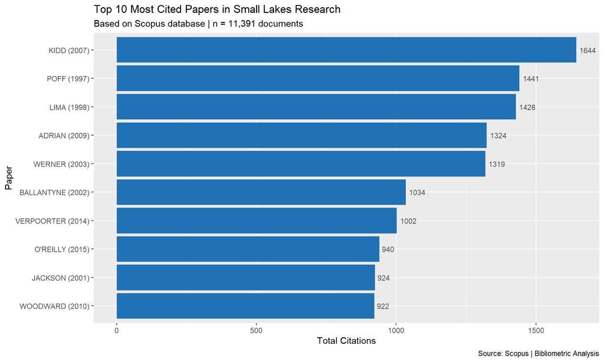

```r
cited_df <- scopus_clean %>%
  select(TI, AU, PY, SO, TC) %>%
  arrange(desc(TC)) %>%
  slice_head(n = 10) %>%
  mutate(
    Label = paste0(word(AU, 1), " (", PY, ")"),
    TI = str_trunc(TI, 50)
  )

ggplot(cited_df, aes(x = reorder(Label, TC), y = TC)) +
  geom_bar(stat = "identity", fill = "#2171b5") +
  geom_text(aes(label = TC), hjust = -0.2, size = 3, color = "gray30") +
  coord_flip() +
  labs(
    title = "Top 10 Most Cited Papers in Small Lakes Research",
    subtitle = "Based on Scopus database | n = 11,391 documents",
    x = "Paper",
    y = "Total Citations",
    caption = "Source: Scopus | Bibliometric Analysis"
  )
```

## 6. Conclusion

The United States, China, and Canada emerged as the most productive countries, while *Hydrobiologia* and the *Journal of Paleolimnology* were identified as the leading publication outlets. The high international co-authorship rate of 27.71% and an average of 4.53 co-authors per document suggest that small lake research is increasingly collaborative and globally engaged.

Thematic analysis of author keywords revealed that the dominant research themes revolve around **climate change**, **eutrophication**, **phytoplankton**, and **paleolimnology** — all of which are rooted in the natural sciences. This pattern is consistent with the broader observation that small lake research has historically been concentrated in ecological and hydrological dimensions, with comparatively little attention given to the social and economic aspects of these water bodies.

This gap represents a significant opportunity for future research. Small lakes, despite being numerically dominant and biologically active, remain underexplored in terms of their socio-economic contributions to surrounding communities — including their roles in supporting local livelihoods, fisheries, aquaculture, and rural economies. Future studies that bridge the natural and social sciences in the context of small lake research would contribute meaningfully to a more holistic understanding of these ecosystems and their value to human communities.